# Examen Final de Análisis y Diseños de Experimentos

#### El tequila es una bebida que está sujeta a una norma oficial mexicana, y conforme a ésta se debe cumplir con ciertas especificaciones físico-químicas. En un laboratorio de investigación, mediante un diseño factorial 25 no replicado, se estudió la influencia de diversos factores sobre la producción de alcoholes superiores en la etapa de fermentación. Los factores estudiados y los niveles fueron: tipo de cepa, A(1, 2), temperatura, B(30, 35°C), fuente de nitrógeno, C(NH4)2SO4 y urea-, relación carbono/nitrógeno, D(62/1, 188/1) y porcentaje de inóculo, E(5 y 10%). En la siguiente tabla se muestran los resultados obtenidos en cuanto a alcohol isoamílico (mg/L), que es par te de los alcoholes superiores

(1)=21.4 d=42.5 e=32.9 de=54.0 a=16.8 ad=21.0 ae=17.5 ade=21.8 b=29.3 bd=79.1 be=30.0 bde=79.9 ab=12.7 abd=20.0 abe=24.1 abde=31.5 c=27.5 cd=48.6 ce=26.7 cde=47.9 ac=22.9 acd=27.1 ace=11.4 acde=15.6 bc=35.4 bcd=85.2 bce=23.9 bcde=73.8 abc=18.8 abcd=26.1 abce=18.0 abcde=25.4

y<-c(21.4, 16.8, 29.3, 12.7, 27.5, 22.9, 35.4, 18.8, 42.5, 21.0, 79.1, 20.0, 48.6, 27.1, 85.2, 26.1, 32.9, 17.5, 30.0, 24.1, 26.7, 11.4, 23.9, 18.0, 54.0, 21.8, 79.9, 31.5, 47.9, 15.6, 73.8, 25.4)

#### a). Estime los efectos y grafique en gráfico de probabilidad normal. De acuerdo a los resultados obtenidos, presente el cuadro de ANVA más conveniente, analice y dé sus conclusiones en término de enunciado. (5 puntos)

```r
#
y<-c(21.4, 16.8, 29.3, 12.7, 27.5, 22.9, 35.4, 18.8, 42.5, 21.0, 79.1, 20.0, 48.6, 27.1, 85.2, 26.1, 32.9, 17.5, 30.0, 24.1, 26.7, 11.4, 23.9, 18.0, 54.0, 21.8, 79.9, 31.5, 47.9, 15.6, 73.8, 25.4)

#
A <- rep(c(rep(-1, 1) , rep(1, 1)) , 16)
B <- rep(c(rep(-1, 2) , rep(1, 2)) ,  8)
C <- rep(c(rep(-1, 4) , rep(1, 4)) ,  4)
D <- rep(c(rep(-1, 8) , rep(1, 8)) ,  2)
E <- rep(c(rep(-1,16) , rep(1,16)) ,  1)
#
printmat("y ",y)
```

```
## [1] "y :  [1] 21.4 16.8 29.3 12.7 27.5 22.9 35.4 18.8 42.5 21.0 79.1 20.0 48.6 27.1"
## [2] "y : [15] 85.2 26.1 32.9 17.5 30.0 24.1 26.7 11.4 23.9 18.0 54.0 21.8 79.9 31.5"
## [3] "y : [29] 47.9 15.6 73.8 25.4"
```

```r
printmat("A ",A)
```

```
## [1] "A :  [1] -1  1 -1  1 -1  1 -1  1 -1  1 -1  1 -1  1 -1  1 -1  1 -1  1 -1  1 -1"
## [2] "A : [24]  1 -1  1 -1  1 -1  1 -1  1"
```

```r
printmat("B ",B)
```

```
## [1] "B :  [1] -1 -1  1  1 -1 -1  1  1 -1 -1  1  1 -1 -1  1  1 -1 -1  1  1 -1 -1  1"
## [2] "B : [24]  1 -1 -1  1  1 -1 -1  1  1"
```

```r
printmat("C ",C)
```

```
## [1] "C :  [1] -1 -1 -1 -1  1  1  1  1 -1 -1 -1 -1  1  1  1  1 -1 -1 -1 -1  1  1  1"
## [2] "C : [24]  1 -1 -1 -1 -1  1  1  1  1"
```

```r
printmat("D ",D)
```

```
## [1] "D :  [1] -1 -1 -1 -1 -1 -1 -1 -1  1  1  1  1  1  1  1  1 -1 -1 -1 -1 -1 -1 -1"
## [2] "D : [24] -1  1  1  1  1  1  1  1  1"
```

```r
printmat("E ",E)
```

```
## [1] "E :  [1] -1 -1 -1 -1 -1 -1 -1 -1 -1 -1 -1 -1 -1 -1 -1 -1  1  1  1  1  1  1  1"
## [2] "E : [24]  1  1  1  1  1  1  1  1  1"
```

```r
# length(A)
# length(y)
mod <- lm(y~A*B*C*D*E)
Estimados <- 2*coefficients(mod)[-1]  # Se retira la columna del intercepto
# Estimados
round(Estimados, 0)
```

```
##         A         B         C         D         E       A:B       A:C
##       -25        10         0        21         0        -7         0
##       B:C       A:D       B:D       C:D       A:E       B:E       C:E
##         0       -15         8         0         0         0        -6
##       D:E     A:B:C     A:B:D     A:C:D     B:C:D     A:B:E     A:C:E
##         0         0        -6         0         0         5         0
##     B:C:E     A:D:E     B:D:E     C:D:E   A:B:C:D   A:B:C:E   A:B:D:E
##         0         0         0         0         0         0         0
##   A:C:D:E   B:C:D:E A:B:C:D:E
##         0         0         0
```

Hay que buscar los estimados que mas aportan al modelo

```r
# data.frame(Estimados)
data.frame(round(Estimados, 0))
```

```
##           round.Estimados..0.
## A                         -25
## B                          10
## C                           0
## D                          21
## E                           0
## A:B                        -7
## A:C                         0
## B:C                         0
## A:D                       -15
## B:D                         8
## C:D                         0
## A:E                         0
## B:E                         0
## C:E                        -6
## D:E                         0
## A:B:C                       0
## A:B:D                      -6
## A:C:D                       0
## B:C:D                       0
## A:B:E                       5
## A:C:E                       0
## B:C:E                       0
## A:D:E                       0
## B:D:E                       0
## C:D:E                       0
## A:B:C:D                     0
## A:B:C:E                     0
## A:B:D:E                     0
## A:C:D:E                     0
## B:C:D:E                     0
## A:B:C:D:E                   0
```

Quienes mas aportan son: 1,2,4,6,9,10,14,17,20

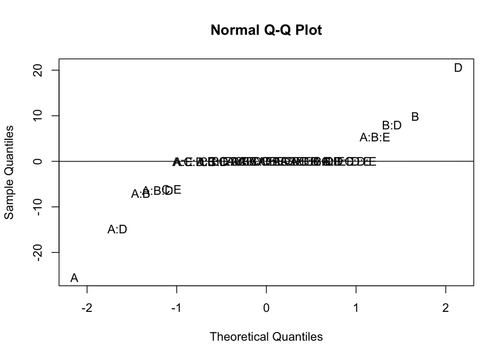

```r
qq <- qqnorm(Estimados,type="n")
Efectos <- names(Estimados)
text(qq$x, qq$y, labels = Efectos)
Estimados1 <- Estimados[-c(1,2,4,6,9,10,14,17,20)] # SON LOS VALORES QUE MAS APORTAN AL MODELO
# Estimados1 <- Estimados
qqline(Estimados1)
```

```r
mod1  <- lm(y ~ A + B + D + A*B + A*D + B*D + C*E + A*B*D + A*B*E)
anva1 <- aov(mod1)
summary(anva1)
```

```
##             Df Sum Sq Mean Sq     F value              Pr(>F)
## A            1   5187    5187 4668040.125 <0.0000000000000002 ***
## B            1    776     776  698562.000 <0.0000000000000002 ***
## D            1   3407    3407 3066526.125 <0.0000000000000002 ***
## C            1      0       0       1.125               0.303
## E            1      0       0       0.000               1.000
## A:B          1    396     396  356590.125 <0.0000000000000002 ***
## A:D          1   1764    1764 1587762.000 <0.0000000000000002 ***
## B:D          1    507     507  456490.125 <0.0000000000000002 ***
## C:E          1    299     299  269011.125 <0.0000000000000002 ***
## A:E          1      0       0       1.125               0.303
## B:E          1      0       0       0.000               1.000
## A:B:D        1    328     328  294912.000 <0.0000000000000002 ***
## A:B:E        1    230     230  207046.125 <0.0000000000000002 ***
## Residuals   18      0       0
## ---
## Signif. codes:  0 '***' 0.001 '**' 0.01 '*' 0.05 '.' 0.1 ' ' 1
```

No se encontró diferencias significativas

- entre A = tipo de cepa con E = porcentaje de inóculo
- entre B = temperatura con E = porcentaje de inóculo

#### b). Suponga que en este experimento, en lugar de que se haya realizado una réplica completa, debido a limitaciones experimentales de en un solo día solo se puede realizar ocho corrida, razón por la cual se tuvo que confundir las siguientes interacciones ACD y BCE para ,formar los bloques que se deben realizar.

##### b.1) Muestre el plan experimental distribuyendo las combinaciones de tratamiento en sus respectivos bloques. Deduzca la interacción generalizada. (5 puntos)

##### b.2) Obtenga el cuadro de ANVA más conveniente para analizar estos resultados. Realice las pruebas de hipótesis sobre los efectos que son significativos. Concluya en término de enunciados. (5 puntos)

#### c). Suponga que se desea realizar solo una fracción del diseño 25con generadores D=AB y E=AC, genere la estructura de alias, obtenga la fracción a realizar y analice la fracción obtenida. Compare con las conclusiones obtenidas en (a) y (b) (5 puntos)